# Regression: Canadian Oil and Gas Stock Price Prediction using Company Balance Sheets

### Retrieving the Dataset

```r
# importing the csv file
data = read.csv("stock_price_prediction_oil_gas.csv")
# removing the Date and X columns from the dataset as we do not need them for our model
data = subset(data, select = -c(Date, X))
```

### Model Selection

```r
# creating the full base model with all of the variables in the dataset
model = lm(ClosingStockPrice~., data = data)
```

```r
# stepwise model selection
stepmod = ols_step_both_p(model, pent = 0.1, prem = 0.3, details = FALSE)
summary(stepmod$model)
```

```
##
## Call:
## lm(formula = paste(response, "~", paste(preds, collapse = " + ")),
##     data = l)
##
## Residuals:
##     Min      1Q  Median      3Q     Max
## -67.808 -11.734  -1.628  12.971  57.069
##
## Coefficients:
##                                                  Estimate        Std. Error
## (Intercept)                             152.8114288023246   8.1663769374114
## Ordinary.Shares.Number                   -0.0000001157462   0.0000000088537
## Total.Equity.Gross.Minority.Interest      0.0000000061846   0.0000000008195
## Non.Current.Deferred.Taxes.Liabilities   -0.0000000086204   0.0000000014856
## Total.Liabilities.Net.Minority.Interest  -0.0000000009984   0.0000000001808
## Net.Tangible.Assets                      -0.0000000020030   0.0000000004624
## Inventory                                -0.0000000037292   0.0000000012924
##                                         t value             Pr(>|t|)
## (Intercept)                              18.712 < 0.0000000000000002 ***
## Ordinary.Shares.Number                  -13.073 < 0.0000000000000002 ***
## Total.Equity.Gross.Minority.Interest      7.547       0.000000000221 ***
## Non.Current.Deferred.Taxes.Liabilities   -5.803       0.000000229211 ***
## Total.Liabilities.Net.Minority.Interest  -5.522       0.000000676929 ***
## Net.Tangible.Assets                      -4.332       0.000054066521 ***
## Inventory                                -2.885              0.00535 **
## ---
## Signif. codes:  0 '***' 0.001 '**' 0.01 '*' 0.05 '.' 0.1 ' ' 1
##
## Residual standard error: 27.03 on 63 degrees of freedom
## Multiple R-squared:  0.8002, Adjusted R-squared:  0.7812
## F-statistic: 42.06 on 6 and 63 DF,  p-value: < 0.00000000000000022
```

```r
# backwards model selection
backmodel = ols_step_backward_p(model, prem = 0.3, details = FALSE)
```

[output not shown]

```r
summary(backmodel$model)
```

```
##
## Call:
## lm(formula = paste(response, "~", paste(preds, collapse = " + ")),
##     data = l)
##
## Residuals:
##     Min      1Q  Median      3Q     Max
## -33.703  -6.204   0.653   6.098  45.722
##
## Coefficients: (5 not defined because of singularities)
##                                                              Estimate
## (Intercept)                                         149.8353883058315
## Ordinary.Shares.Number                               -0.0000003664604
## Share.Issued                                          0.0000002227658
## Net.Debt                                             -0.0000000138273
## Total.Debt                                           -0.0000001711251
## Tangible.Book.Value                                   0.0000000065759
## Invested.Capital                                     -0.0000000013952
## Working.Capital                                      -0.0000000103049
## Net.Tangible.Assets                                  -0.0000000214254
## Common.Stock.Equity                                   0.0000000047322
## Total.Equity.Gross.Minority.Interest                  0.0000000090132
## Stockholders.Equity                                                NA
## Retained.Earnings                                    -0.0000000010908
## Capital.Stock                                         0.0000000037502
## Common.Stock                                                       NA
## Total.Liabilities.Net.Minority.Interest               0.0000000017244
## Total.Non.Current.Liabilities.Net.Minority.Interest  -0.0000000172353
## Non.Current.Deferred.Liabilities                      0.0000000014961
## Non.Current.Deferred.Taxes.Liabilities               -0.0000000157810
## Long.Term.Debt.And.Capital.Lease.Obligation           0.0000001919806
## Current.Liabilities                                  -0.0000000467138
## Current.Debt.And.Capital.Lease.Obligation             0.0000002086864
## Payables.And.Accrued.Expenses                         0.0000000545805
## Payables                                             -0.0000000190818
## Total.Assets                                                       NA
## Total.Non.Current.Assets                                           NA
## Net.PPE                                               0.0000000099156
## Current.Assets                                                     NA
## Inventory                                             0.0000000099265
```

[output cut: 57 more lines]

```
## Payables.And.Accrued.Expenses                       0.00001060580516 ***
## Payables                                                    0.028401 *
## Total.Assets                                                      NA
## Total.Non.Current.Assets                                          NA
## Net.PPE                                                     0.027953 *
## Current.Assets                                                    NA
## Inventory                                                   0.138234
## Receivables                                                 0.006935 **
## Accounts.Receivable                                         0.000714 ***
## ---
## Signif. codes:  0 '***' 0.001 '**' 0.01 '*' 0.05 '.' 0.1 ' ' 1
##
## Residual standard error: 16.33 on 44 degrees of freedom
## Multiple R-squared:  0.9491, Adjusted R-squared:  0.9202
## F-statistic: 32.82 on 25 and 44 DF,  p-value: < 0.00000000000000022
```

```r
# forward model selection
formodel = ols_step_forward_p(model, penter = 0.1, details = FALSE)
summary(formodel$model)
```

```
##
## Call:
## lm(formula = paste(response, "~", paste(preds, collapse = " + ")),
##     data = l)
##
## Residuals:
##     Min      1Q  Median      3Q     Max
## -67.876 -10.789  -1.614  13.457  58.837
##
## Coefficients:
##                                                  Estimate        Std. Error
## (Intercept)                             151.4017499755188   8.6588640789938
## Working.Capital                           0.0000000007645   0.0000000014851
## Ordinary.Shares.Number                   -0.0000001135682   0.0000000098597
## Total.Equity.Gross.Minority.Interest      0.0000000061204   0.0000000008336
## Non.Current.Deferred.Taxes.Liabilities   -0.0000000081162   0.0000000017867
## Total.Liabilities.Net.Minority.Interest  -0.0000000009841   0.0000000001840
## Net.Tangible.Assets                      -0.0000000020417   0.0000000004711
## Inventory                                -0.0000000047109   0.0000000023080
##                                         t value             Pr(>|t|)
## (Intercept)                              17.485 < 0.0000000000000002 ***
## Working.Capital                           0.515               0.6085
## Ordinary.Shares.Number                  -11.518 < 0.0000000000000002 ***
## Total.Equity.Gross.Minority.Interest      7.342        0.00000000055 ***
## Non.Current.Deferred.Taxes.Liabilities   -4.543        0.00002623148 ***
## Total.Liabilities.Net.Minority.Interest  -5.349        0.00000135320 ***
## Net.Tangible.Assets                      -4.334        0.00005471156 ***
## Inventory                                -2.041               0.0455 *
## ---
## Signif. codes:  0 '***' 0.001 '**' 0.01 '*' 0.05 '.' 0.1 ' ' 1
##
## Residual standard error: 27.19 on 62 degrees of freedom
## Multiple R-squared:  0.8011, Adjusted R-squared:  0.7786
## F-statistic: 35.67 on 7 and 62 DF,  p-value: < 0.00000000000000022
```

```r
# choosing consistantly present variables from all of the model selection methods
model = lm(ClosingStockPrice~Ordinary.Shares.Number+Total.Equity.Gross.Minority.Interest+Non.Current.Deferred.Taxes.Liabilities+Total.Liabilities.Net.Minority.Interest+Net.Tangible.Assets+Inventory, data = data)
summary(model)
```

```
##
## Call:
## lm(formula = ClosingStockPrice ~ Ordinary.Shares.Number + Total.Equity.Gross.Minority.Interest +
##     Non.Current.Deferred.Taxes.Liabilities + Total.Liabilities.Net.Minority.Interest +
##     Net.Tangible.Assets + Inventory, data = data)
##
## Residuals:
##     Min      1Q  Median      3Q     Max
## -67.808 -11.734  -1.628  12.971  57.069
##
## Coefficients:
##                                                  Estimate        Std. Error
## (Intercept)                             152.8114288023246   8.1663769374114
## Ordinary.Shares.Number                   -0.0000001157462   0.0000000088537
## Total.Equity.Gross.Minority.Interest      0.0000000061846   0.0000000008195
## Non.Current.Deferred.Taxes.Liabilities   -0.0000000086204   0.0000000014856
## Total.Liabilities.Net.Minority.Interest  -0.0000000009984   0.0000000001808
## Net.Tangible.Assets                      -0.0000000020030   0.0000000004624
## Inventory                                -0.0000000037292   0.0000000012924
##                                         t value             Pr(>|t|)
## (Intercept)                              18.712 < 0.0000000000000002 ***
## Ordinary.Shares.Number                  -13.073 < 0.0000000000000002 ***
## Total.Equity.Gross.Minority.Interest      7.547       0.000000000221 ***
## Non.Current.Deferred.Taxes.Liabilities   -5.803       0.000000229211 ***
## Total.Liabilities.Net.Minority.Interest  -5.522       0.000000676929 ***
## Net.Tangible.Assets                      -4.332       0.000054066521 ***
## Inventory                                -2.885              0.00535 **
## ---
## Signif. codes:  0 '***' 0.001 '**' 0.01 '*' 0.05 '.' 0.1 ' ' 1
##
## Residual standard error: 27.03 on 63 degrees of freedom
## Multiple R-squared:  0.8002, Adjusted R-squared:  0.7812
## F-statistic: 42.06 on 6 and 63 DF,  p-value: < 0.00000000000000022
```

### Checking for Higher Order Terms

Now, we can check for any terms with a higher order relationship with ClosingStockPrice.

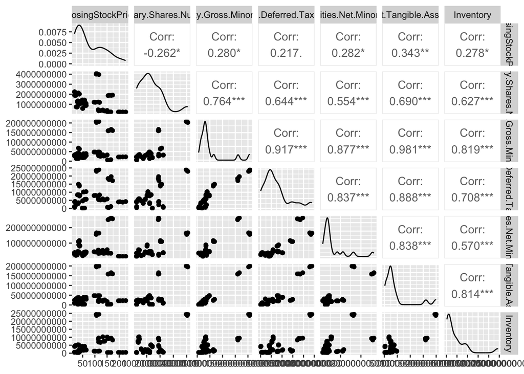

```r
# checking for higher order terms
ggpairs(data[, c("ClosingStockPrice", "Ordinary.Shares.Number", "Total.Equity.Gross.Minority.Interest",
    "Non.Current.Deferred.Taxes.Liabilities", "Total.Liabilities.Net.Minority.Interest",
    "Net.Tangible.Assets", "Inventory")])
```

It appears there are no higher order terms present in the model.

### Checking for Interaction Terms

Now, we can check for any interaction terms between the variables in the model.

```r
# checking for interaction terms
interactmodel = lm(ClosingStockPrice~(Ordinary.Shares.Number+Total.Equity.Gross.Minority.Interest+Non.Current.Deferred.Taxes.Liabilities+Total.Liabilities.Net.Minority.Interest+Net.Tangible.Assets+Inventory)^2, data = data)
summary(interactmodel)
```

```
##
## Call:
## lm(formula = ClosingStockPrice ~ (Ordinary.Shares.Number + Total.Equity.Gross.Minority.Interest +
##     Non.Current.Deferred.Taxes.Liabilities + Total.Liabilities.Net.Minority.Interest +
##     Net.Tangible.Assets + Inventory)^2, data = data)
##
## Residuals:
##    Min     1Q Median     3Q    Max
## -54.89 -12.48   3.02  16.56  36.08
##
## Coefficients:
##                                                                                                  Estimate
## (Intercept)                                                                    80.33147321155202291720343
## Ordinary.Shares.Number                                                         -0.00000007634589380140556
## Total.Equity.Gross.Minority.Interest                                            0.00000000660440031751353
## Non.Current.Deferred.Taxes.Liabilities                                          0.00000000827009583291538
## Total.Liabilities.Net.Minority.Interest                                         0.00000000165885485928724
## Net.Tangible.Assets                                                            -0.00000000508213521251788
## Inventory                                                                      -0.00000001269262745570132
## Ordinary.Shares.Number:Total.Equity.Gross.Minority.Interest                    -0.00000000000000000278672
## Ordinary.Shares.Number:Non.Current.Deferred.Taxes.Liabilities                  -0.00000000000000002788870
## Ordinary.Shares.Number:Total.Liabilities.Net.Minority.Interest                 -0.00000000000000000020551
## Ordinary.Shares.Number:Net.Tangible.Assets                                      0.00000000000000000237473
## Ordinary.Shares.Number:Inventory                                                0.00000000000000003152674
## Total.Equity.Gross.Minority.Interest:Non.Current.Deferred.Taxes.Liabilities     0.00000000000000000164680
## Total.Equity.Gross.Minority.Interest:Total.Liabilities.Net.Minority.Interest    0.00000000000000000007687
## Total.Equity.Gross.Minority.Interest:Net.Tangible.Assets                        0.00000000000000000009061
## Total.Equity.Gross.Minority.Interest:Inventory                                 -0.00000000000000000363915
## Non.Current.Deferred.Taxes.Liabilities:Total.Liabilities.Net.Minority.Interest -0.00000000000000000061264
## Non.Current.Deferred.Taxes.Liabilities:Net.Tangible.Assets                     -0.00000000000000000083188
## Non.Current.Deferred.Taxes.Liabilities:Inventory                                0.00000000000000000176165
## Total.Liabilities.Net.Minority.Interest:Net.Tangible.Assets                    -0.00000000000000000011965
## Total.Liabilities.Net.Minority.Interest:Inventory                               0.00000000000000000100621
## Net.Tangible.Assets:Inventory                                                   0.00000000000000000186534
##                                                                                                Std. Error
## (Intercept)                                                                    33.38391167910133816576490
## Ordinary.Shares.Number                                                          0.00000003551940987906891
## Total.Equity.Gross.Minority.Interest                                            0.00000000497692586946298
## Non.Current.Deferred.Taxes.Liabilities                                          0.00000001306555708966518
## Total.Liabilities.Net.Minority.Interest                                         0.00000000113340597339548
```

[output cut: 77 more lines]

```
## Total.Equity.Gross.Minority.Interest:Total.Liabilities.Net.Minority.Interest
## Total.Equity.Gross.Minority.Interest:Net.Tangible.Assets                       .
## Total.Equity.Gross.Minority.Interest:Inventory                                 ***
## Non.Current.Deferred.Taxes.Liabilities:Total.Liabilities.Net.Minority.Interest **
## Non.Current.Deferred.Taxes.Liabilities:Net.Tangible.Assets
## Non.Current.Deferred.Taxes.Liabilities:Inventory
## Total.Liabilities.Net.Minority.Interest:Net.Tangible.Assets                    .
## Total.Liabilities.Net.Minority.Interest:Inventory                              ***
## Net.Tangible.Assets:Inventory                                                  ***
## ---
## Signif. codes:  0 '***' 0.001 '**' 0.01 '*' 0.05 '.' 0.1 ' ' 1
##
## Residual standard error: 23.48 on 48 degrees of freedom
## Multiple R-squared:  0.8852, Adjusted R-squared:  0.8349
## F-statistic: 17.62 on 21 and 48 DF,  p-value: 0.0000000000000006547
```

```r
# removing insignificant interaction terms
model = lm(ClosingStockPrice~Ordinary.Shares.Number+Total.Equity.Gross.Minority.Interest+Non.Current.Deferred.Taxes.Liabilities+Total.Liabilities.Net.Minority.Interest+Net.Tangible.Assets+Inventory+Ordinary.Shares.Number:Inventory+Total.Equity.Gross.Minority.Interest:Inventory+Non.Current.Deferred.Taxes.Liabilities:Total.Liabilities.Net.Minority.Interest+Total.Liabilities.Net.Minority.Interest:Inventory+Net.Tangible.Assets:Inventory, data = data)
summary(model)
```

```
##
## Call:
## lm(formula = ClosingStockPrice ~ Ordinary.Shares.Number + Total.Equity.Gross.Minority.Interest +
##     Non.Current.Deferred.Taxes.Liabilities + Total.Liabilities.Net.Minority.Interest +
##     Net.Tangible.Assets + Inventory + Ordinary.Shares.Number:Inventory +
##     Total.Equity.Gross.Minority.Interest:Inventory + Non.Current.Deferred.Taxes.Liabilities:Total.Liabilities.Net.Minority.Interest +
##     Total.Liabilities.Net.Minority.Interest:Inventory + Net.Tangible.Assets:Inventory,
##     data = data)
##
## Residuals:
##     Min      1Q  Median      3Q     Max
## -69.191 -14.802   1.253  16.632  44.381
##
## Coefficients:
##                                                                                                   Estimate
## (Intercept)                                                                    155.54054798049335772702761
## Ordinary.Shares.Number                                                          -0.00000015067017258896197
## Total.Equity.Gross.Minority.Interest                                             0.00000000861748867341614
## Non.Current.Deferred.Taxes.Liabilities                                          -0.00000000933066260732016
## Total.Liabilities.Net.Minority.Interest                                         -0.00000000100373125963948
## Net.Tangible.Assets                                                             -0.00000000337519272781414
## Inventory                                                                       -0.00000000559253437053805
## Ordinary.Shares.Number:Inventory                                                 0.00000000000000000854450
## Total.Equity.Gross.Minority.Interest:Inventory                                  -0.00000000000000000047129
## Non.Current.Deferred.Taxes.Liabilities:Total.Liabilities.Net.Minority.Interest  -0.00000000000000000002544
## Total.Liabilities.Net.Minority.Interest:Inventory                                0.00000000000000000009183
## Net.Tangible.Assets:Inventory                                                    0.00000000000000000025490
##                                                                                                 Std. Error
## (Intercept)                                                                     14.77237933092661492651132
## Ordinary.Shares.Number                                                           0.00000001490185417712524
## Total.Equity.Gross.Minority.Interest                                             0.00000000145850491382388
## Non.Current.Deferred.Taxes.Liabilities                                           0.00000000258409380621136
## Total.Liabilities.Net.Minority.Interest                                          0.00000000039895878313128
## Net.Tangible.Assets                                                              0.00000000105799623776353
## Inventory                                                                        0.00000000311309065337500
## Ordinary.Shares.Number:Inventory                                                 0.00000000000000000280937
## Total.Equity.Gross.Minority.Interest:Inventory                                   0.00000000000000000028775
## Non.Current.Deferred.Taxes.Liabilities:Total.Liabilities.Net.Minority.Interest   0.00000000000000000003703
## Total.Liabilities.Net.Minority.Interest:Inventory                                0.00000000000000000009018
## Net.Tangible.Assets:Inventory                                                    0.00000000000000000024093
```

[output cut: 30 more lines]

```
## Non.Current.Deferred.Taxes.Liabilities                                         ***
## Total.Liabilities.Net.Minority.Interest                                        *
## Net.Tangible.Assets                                                            **
## Inventory                                                                      .
## Ordinary.Shares.Number:Inventory                                               **
## Total.Equity.Gross.Minority.Interest:Inventory
## Non.Current.Deferred.Taxes.Liabilities:Total.Liabilities.Net.Minority.Interest
## Total.Liabilities.Net.Minority.Interest:Inventory
## Net.Tangible.Assets:Inventory
## ---
## Signif. codes:  0 '***' 0.001 '**' 0.01 '*' 0.05 '.' 0.1 ' ' 1
##
## Residual standard error: 26.06 on 58 degrees of freedom
## Multiple R-squared:  0.8291, Adjusted R-squared:  0.7967
## F-statistic: 25.58 on 11 and 58 DF,  p-value: < 0.00000000000000022
```

```r
# removing insignificant interaction terms
model = lm(ClosingStockPrice~Ordinary.Shares.Number+Total.Equity.Gross.Minority.Interest+Non.Current.Deferred.Taxes.Liabilities+Total.Liabilities.Net.Minority.Interest+Net.Tangible.Assets+Inventory+Ordinary.Shares.Number:Inventory, data = data)
summary(model)
```

```
##
## Call:
## lm(formula = ClosingStockPrice ~ Ordinary.Shares.Number + Total.Equity.Gross.Minority.Interest +
##     Non.Current.Deferred.Taxes.Liabilities + Total.Liabilities.Net.Minority.Interest +
##     Net.Tangible.Assets + Inventory + Ordinary.Shares.Number:Inventory,
##     data = data)
##
## Residuals:
##     Min      1Q  Median      3Q     Max
## -67.577 -11.348  -1.618  14.024  56.589
##
## Coefficients:
##                                                           Estimate
## (Intercept)                             155.1978383289223017982295
## Ordinary.Shares.Number                   -0.0000001169041459918169
## Total.Equity.Gross.Minority.Interest      0.0000000060838872335305
## Non.Current.Deferred.Taxes.Liabilities   -0.0000000086039193984958
## Total.Liabilities.Net.Minority.Interest  -0.0000000009452744314242
## Net.Tangible.Assets                      -0.0000000020013716445519
## Inventory                                -0.0000000041536120196795
## Ordinary.Shares.Number:Inventory          0.0000000000000000002635
##                                                         Std. Error t value
## (Intercept)                               9.9857770320123737661788  15.542
## Ordinary.Shares.Number                    0.0000000093270242748805 -12.534
## Total.Equity.Gross.Minority.Interest      0.0000000008588305967454   7.084
## Non.Current.Deferred.Taxes.Liabilities    0.0000000014959039077862  -5.752
## Total.Liabilities.Net.Minority.Interest   0.0000000002214545196126  -4.268
## Net.Tangible.Assets                       0.0000000004654290156810  -4.300
## Inventory                                 0.0000000016459823351920  -2.523
## Ordinary.Shares.Number:Inventory          0.0000000000000000006261   0.421
##                                                     Pr(>|t|)
## (Intercept)                             < 0.0000000000000002 ***
## Ordinary.Shares.Number                  < 0.0000000000000002 ***
## Total.Equity.Gross.Minority.Interest           0.00000000154 ***
## Non.Current.Deferred.Taxes.Liabilities         0.00000029140 ***
## Total.Liabilities.Net.Minority.Interest        0.00006863904 ***
## Net.Tangible.Assets                            0.00006152382 ***
## Inventory                                             0.0142 *
## Ordinary.Shares.Number:Inventory                      0.6753
## ---
## Signif. codes:  0 '***' 0.001 '**' 0.01 '*' 0.05 '.' 0.1 ' ' 1
##
## Residual standard error: 27.21 on 62 degrees of freedom
## Multiple R-squared:  0.8008, Adjusted R-squared:  0.7783
## F-statistic: 35.61 on 7 and 62 DF,  p-value: < 0.00000000000000022
```

```r
# removing insignificant interaction terms
model = lm(ClosingStockPrice~Ordinary.Shares.Number+Total.Equity.Gross.Minority.Interest+Non.Current.Deferred.Taxes.Liabilities+Total.Liabilities.Net.Minority.Interest+Net.Tangible.Assets+Inventory, data = data)
summary(model)
```

```
##
## Call:
## lm(formula = ClosingStockPrice ~ Ordinary.Shares.Number + Total.Equity.Gross.Minority.Interest +
##     Non.Current.Deferred.Taxes.Liabilities + Total.Liabilities.Net.Minority.Interest +
##     Net.Tangible.Assets + Inventory, data = data)
##
## Residuals:
##     Min      1Q  Median      3Q     Max
## -67.808 -11.734  -1.628  12.971  57.069
##
## Coefficients:
##                                                  Estimate        Std. Error
## (Intercept)                             152.8114288023246   8.1663769374114
## Ordinary.Shares.Number                   -0.0000001157462   0.0000000088537
## Total.Equity.Gross.Minority.Interest      0.0000000061846   0.0000000008195
## Non.Current.Deferred.Taxes.Liabilities   -0.0000000086204   0.0000000014856
## Total.Liabilities.Net.Minority.Interest  -0.0000000009984   0.0000000001808
## Net.Tangible.Assets                      -0.0000000020030   0.0000000004624
## Inventory                                -0.0000000037292   0.0000000012924
##                                         t value             Pr(>|t|)
## (Intercept)                              18.712 < 0.0000000000000002 ***
## Ordinary.Shares.Number                  -13.073 < 0.0000000000000002 ***
## Total.Equity.Gross.Minority.Interest      7.547       0.000000000221 ***
## Non.Current.Deferred.Taxes.Liabilities   -5.803       0.000000229211 ***
## Total.Liabilities.Net.Minority.Interest  -5.522       0.000000676929 ***
## Net.Tangible.Assets                      -4.332       0.000054066521 ***
## Inventory                                -2.885              0.00535 **
## ---
## Signif. codes:  0 '***' 0.001 '**' 0.01 '*' 0.05 '.' 0.1 ' ' 1
##
## Residual standard error: 27.03 on 63 degrees of freedom
## Multiple R-squared:  0.8002, Adjusted R-squared:  0.7812
## F-statistic: 42.06 on 6 and 63 DF,  p-value: < 0.00000000000000022
```

### Condition Checking

Now, we must check the 6 core regression assumptions that are necissary to be met, for a sufficient regression model.

Linearity Assumption:

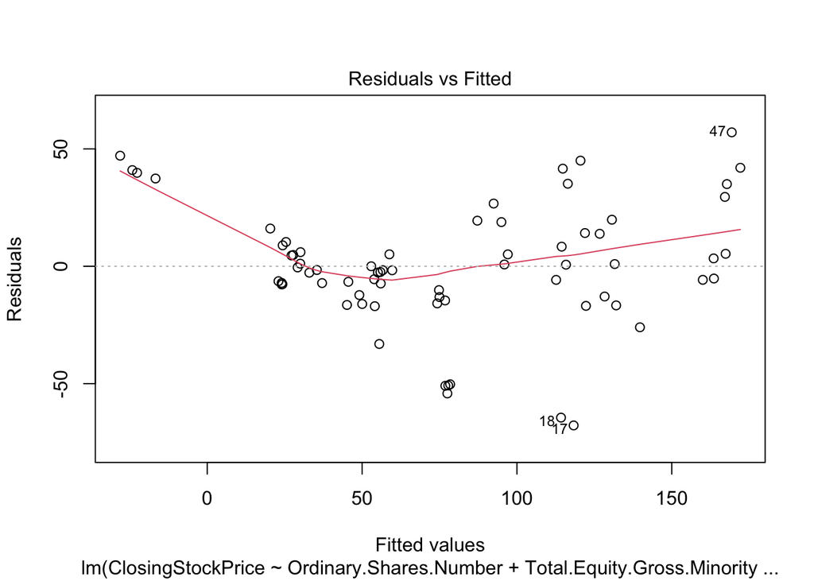

```r
# plotting the residual plot of the model
plot(model, which = 1)
```

It appears that the linearity assumption is not met, as the plot is not consistantly linear.

Normality Assumption:

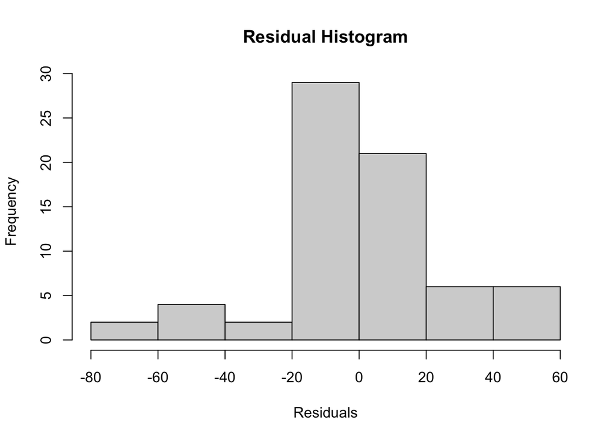

```r
# plotting the residual histogram
hist(residuals(model), main = "Residual Histogram", xlab = "Residuals")
```

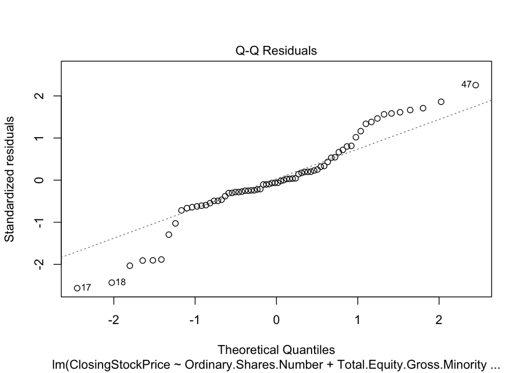

```r
# plotting the Q-Q normality plot
plot(model, which = 2)
```

```r
# conducting the Shapiro-Wilk normality test
shapiro.test(residuals(model))
```

```
##
##  Shapiro-Wilk normality test
##
## data:  residuals(model)
## W = 0.94968, p-value = 0.006974
```

$H_0: $ Normality of Residuals is met.

$H_A: $ Normality of Residuals is not met.

It appears that the normality of the residuals assumption is not met, as the histogram is not a bell-shape, the Q-Q normality plot is not following the diagonal line and we reject the null hypothesis in the Shapiro-Wilk normality test.

Equal Variance Assumption:

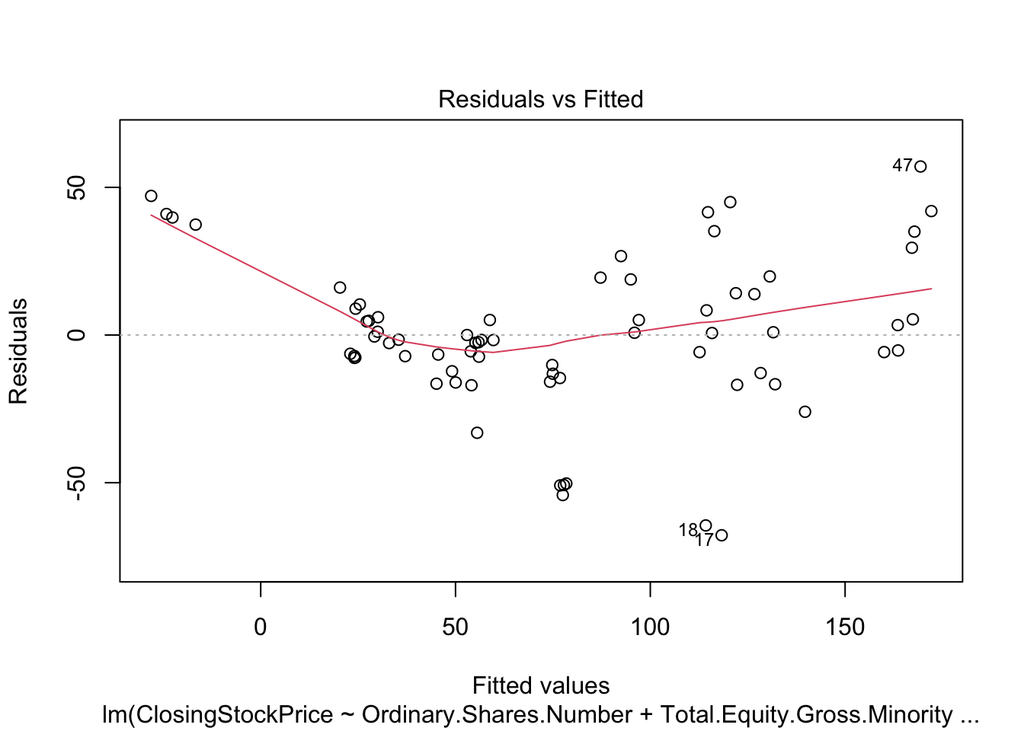

```r
# plotting the residual plot for the model
plot(model, which = 1)
```

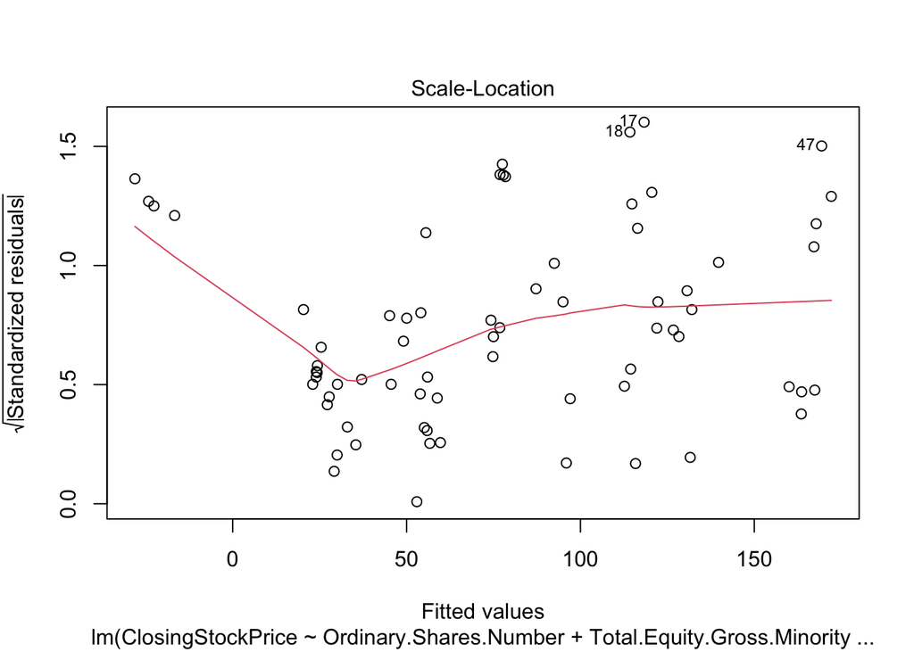

```r
# plotting the scale-location plot
plot(model, which = 3)
```

```r
# conducting the Breusch-Pagan test
bptest(model)
```

```
##
##  studentized Breusch-Pagan test
##
## data:  model
## BP = 16.388, df = 6, p-value = 0.01182
```

$H_0: $The Equal Variance Assumption is met.

$H_A: $The Equal Variance Assumption is not met.

It appears that the equal variance assumption is not met, as the residual plot and scale location plot do not have equal variance for all x values and we reject the null hypothesis in the Breusch-Pagan test.

Independence Assumption:

Independence is assumed by default.

Multicollinearity Assumption:

```r
# conducting the vif test
imcdiag(model, method = "VIF")
```

```
##
## Call:
## imcdiag(mod = model, method = "VIF")
##
##
##  VIF Multicollinearity Diagnostics
##
##                                              VIF detection
## Ordinary.Shares.Number                    6.0894         0
## Total.Equity.Gross.Minority.Interest    167.4231         1
## Non.Current.Deferred.Taxes.Liabilities    7.7002         0
## Total.Liabilities.Net.Minority.Interest  11.3477         1
## Net.Tangible.Assets                      55.1498         1
## Inventory                                 5.2151         0
##
## Multicollinearity may be due to Total.Equity.Gross.Minority.Interest Total.Liabilities.Net.Minority.Interest Net.Tangible.Assets regressors
##
## 1 --> COLLINEARITY is detected by the test
## 0 --> COLLINEARITY is not detected by the test
##
## ===================================
```

It appears that the multicollinearity assumption is not met, as there is collinearity present between 3 variables.

Outliers:

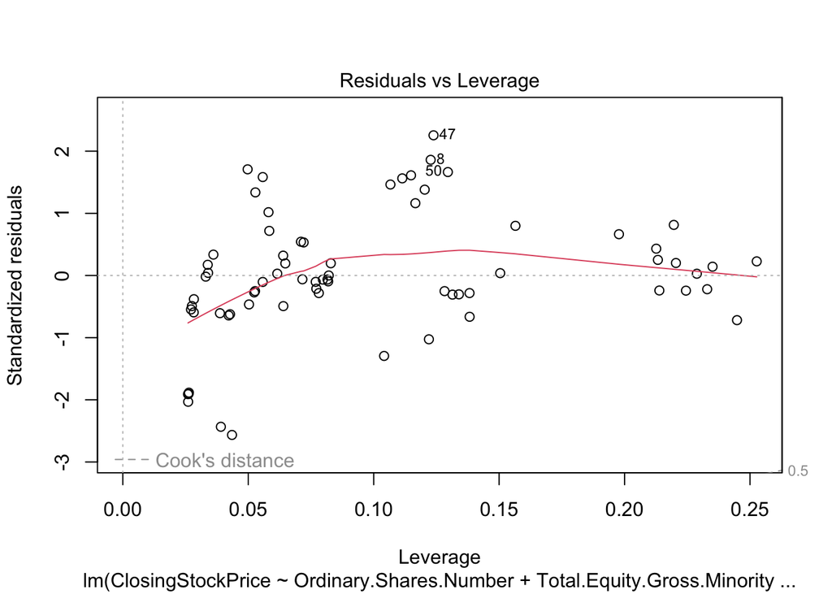

```r
# plotting the residual-leverage plot
plot(model, which = 5)
```

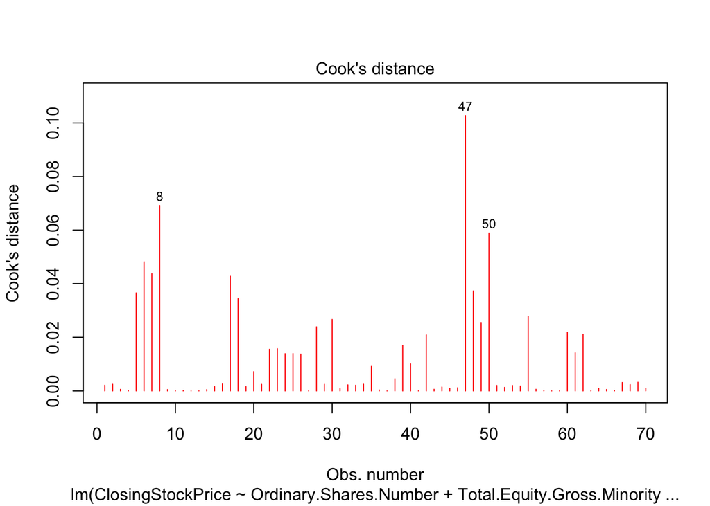

```r
# plotting the cooks distance values
plot(model, pch = 18, col = "red", which = c(4))
```

It appears that the outlier assumption is met, as there are no cooks distance values present above 0.5.

### Box-Cox Transformation

Due to the fact that there are multiple assumptions that have not been met by our model, we can conduct a box-cox tranformation in an attempt to see if it can rectify this issue.

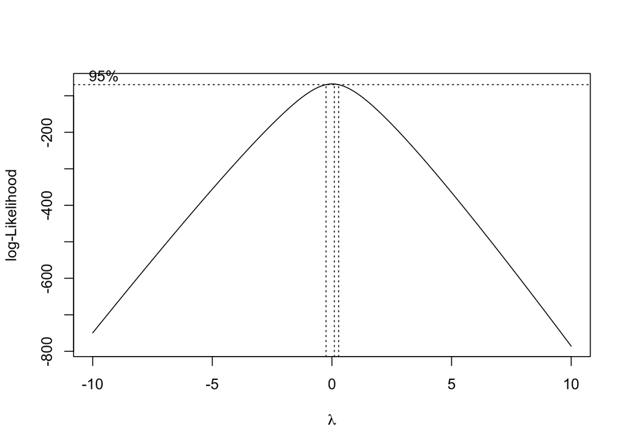

```r
# getting the best lambda value for the box-cox transformation
bc = boxcox(model, lambda = seq(-10, 10), data = data)
```

```r
# getting the best lambda value for the box-cox transformation
best.lambda = bc$x[which(bc$y == max(bc$y))]
# creating the box-cox model
model = lm(formula = (ClosingStockPrice^best.lambda - 1)/best.lambda ~Ordinary.Shares.Number+Total.Equity.Gross.Minority.Interest+Non.Current.Deferred.Taxes.Liabilities+Total.Liabilities.Net.Minority.Interest+Net.Tangible.Assets+Inventory, data = data)
summary(model)
```

```
##
## Call:
## lm(formula = (ClosingStockPrice^best.lambda - 1)/best.lambda ~
##     Ordinary.Shares.Number + Total.Equity.Gross.Minority.Interest +
##         Non.Current.Deferred.Taxes.Liabilities + Total.Liabilities.Net.Minority.Interest +
##         Net.Tangible.Assets + Inventory, data = data)
##
## Residuals:
##     Min      1Q  Median      3Q     Max
## -1.2868 -0.2674  0.1001  0.2847  0.9127
##
## Coefficients:
##                                                   Estimate         Std. Error
## (Intercept)                              6.443255697791944  0.150703257284133
## Ordinary.Shares.Number                  -0.000000002353556  0.000000000163387
## Total.Equity.Gross.Minority.Interest     0.000000000114405  0.000000000015122
## Non.Current.Deferred.Taxes.Liabilities  -0.000000000118039  0.000000000027415
## Total.Liabilities.Net.Minority.Interest -0.000000000019491  0.000000000003336
## Net.Tangible.Assets                     -0.000000000038609  0.000000000008533
## Inventory                               -0.000000000040495  0.000000000023851
##                                         t value             Pr(>|t|)
## (Intercept)                              42.755 < 0.0000000000000002 ***
## Ordinary.Shares.Number                  -14.405 < 0.0000000000000002 ***
## Total.Equity.Gross.Minority.Interest      7.565       0.000000000206 ***
## Non.Current.Deferred.Taxes.Liabilities   -4.306       0.000059320981 ***
## Total.Liabilities.Net.Minority.Interest  -5.842       0.000000196752 ***
## Net.Tangible.Assets                      -4.525       0.000027369581 ***
## Inventory                                -1.698               0.0945 .
## ---
## Signif. codes:  0 '***' 0.001 '**' 0.01 '*' 0.05 '.' 0.1 ' ' 1
##
## Residual standard error: 0.4988 on 63 degrees of freedom
## Multiple R-squared:  0.8387, Adjusted R-squared:  0.8233
## F-statistic:  54.6 on 6 and 63 DF,  p-value: < 0.00000000000000022
```

```r
# removing the inventory variable as it is insignificant now
model = lm(formula = (ClosingStockPrice^best.lambda - 1)/best.lambda ~Ordinary.Shares.Number+Total.Equity.Gross.Minority.Interest+Non.Current.Deferred.Taxes.Liabilities+Total.Liabilities.Net.Minority.Interest+Net.Tangible.Assets, data = data)
summary(model)
```

```
##
## Call:
## lm(formula = (ClosingStockPrice^best.lambda - 1)/best.lambda ~
##     Ordinary.Shares.Number + Total.Equity.Gross.Minority.Interest +
##         Non.Current.Deferred.Taxes.Liabilities + Total.Liabilities.Net.Minority.Interest +
##         Net.Tangible.Assets, data = data)
##
## Residuals:
##      Min       1Q   Median       3Q      Max
## -1.25870 -0.25829  0.08061  0.27032  0.94782
##
## Coefficients:
##                                                   Estimate         Std. Error
## (Intercept)                              6.341048885242374  0.140175811993235
## Ordinary.Shares.Number                  -0.000000002239501  0.000000000151114
## Total.Equity.Gross.Minority.Interest     0.000000000099610  0.000000000012540
## Non.Current.Deferred.Taxes.Liabilities  -0.000000000106217  0.000000000026904
## Total.Liabilities.Net.Minority.Interest -0.000000000015933  0.000000000002634
## Net.Tangible.Assets                     -0.000000000034016  0.000000000008211
##                                         t value             Pr(>|t|)
## (Intercept)                              45.236 < 0.0000000000000002 ***
## Ordinary.Shares.Number                  -14.820 < 0.0000000000000002 ***
## Total.Equity.Gross.Minority.Interest      7.944      0.0000000000405 ***
## Non.Current.Deferred.Taxes.Liabilities   -3.948             0.000199 ***
## Total.Liabilities.Net.Minority.Interest  -6.049      0.0000000835730 ***
## Net.Tangible.Assets                      -4.143             0.000102 ***
## ---
## Signif. codes:  0 '***' 0.001 '**' 0.01 '*' 0.05 '.' 0.1 ' ' 1
##
## Residual standard error: 0.5061 on 64 degrees of freedom
## Multiple R-squared:  0.8313, Adjusted R-squared:  0.8181
## F-statistic: 63.08 on 5 and 64 DF,  p-value: < 0.00000000000000022
```

### Condition Checking

Now, we must check the 6 core regression assumptions that are necissary to be met on the box-cox model.

Linearity Assumption:

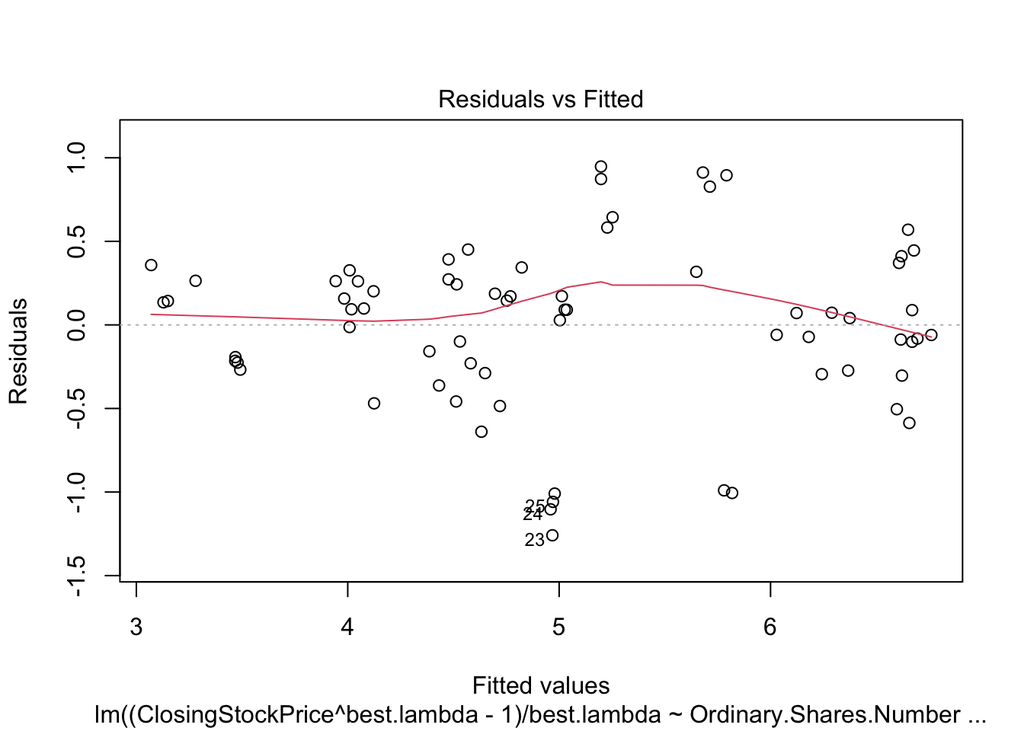

```r
# plotting the residual plot of the model
plot(model, which = 1)
```

It appears that the linearity assumption is now met.

Normality Assumption:

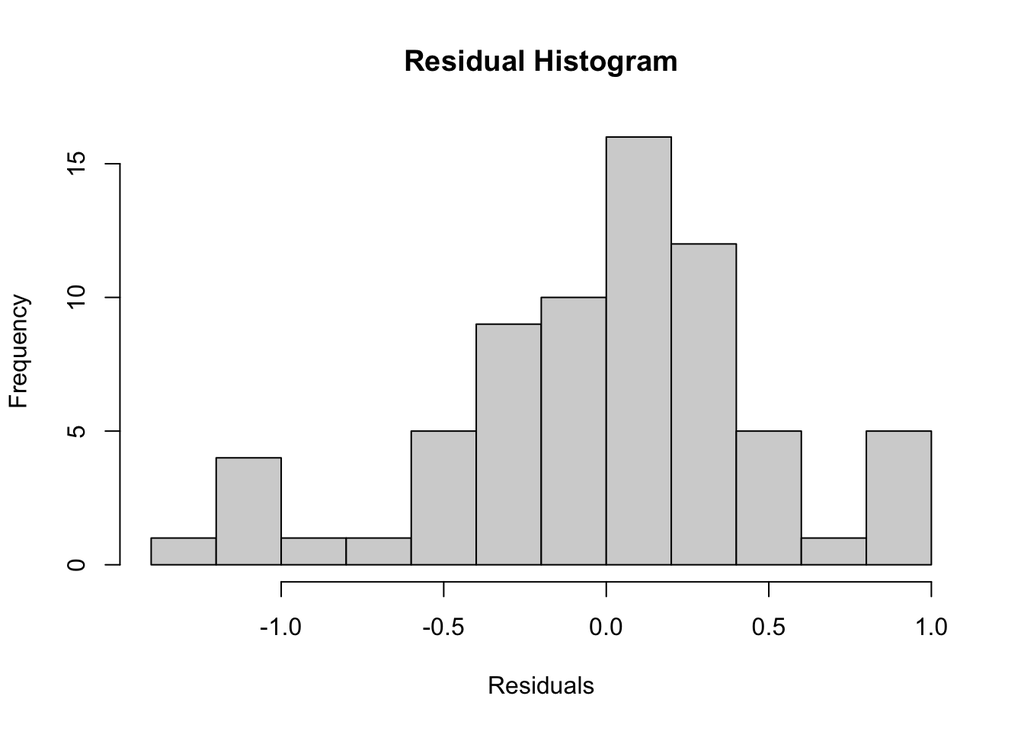

```r
# plotting the residual histogram
hist(residuals(model), main = "Residual Histogram", xlab = "Residuals")
```

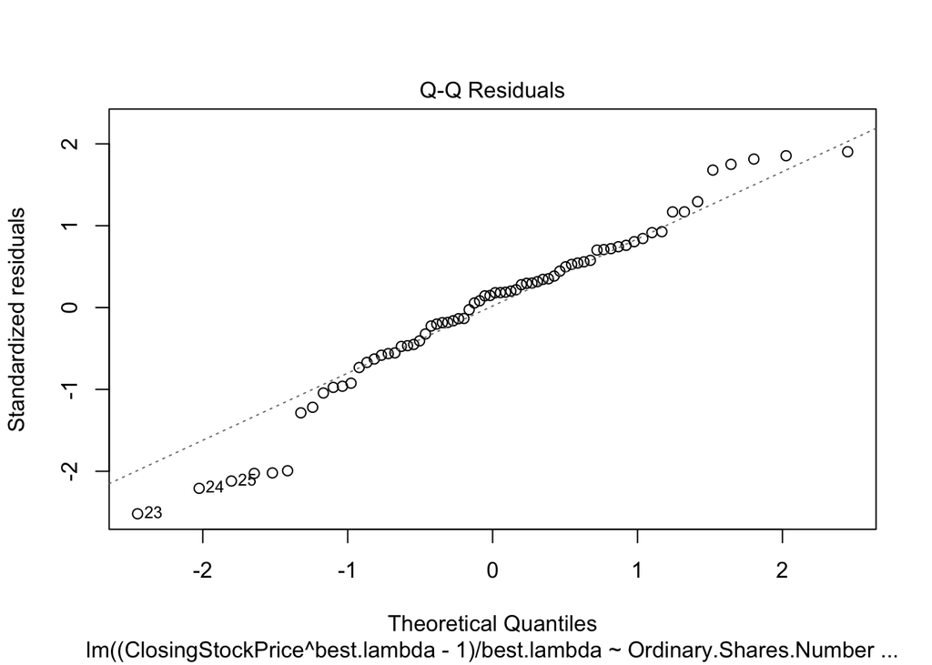

```r
# plotting the Q-Q normality plot
plot(model, which = 2)
```

```r
# conducting the Shapiro-Wilk normality test
shapiro.test(residuals(model))
```

```
##
##  Shapiro-Wilk normality test
##
## data:  residuals(model)
## W = 0.96316, p-value = 0.0375
```

$H_0: $ Normality of Residuals is met.

$H_A: $ Normality of Residuals is not met.

It appears that the normality of the residuals assumption is not met, as the histogram is not a bell-shape, the Q-Q normality plot is not following the diagonal line and we reject the null hypothesis in the Shapiro-Wilk normality test.

Equal Variance Assumption:

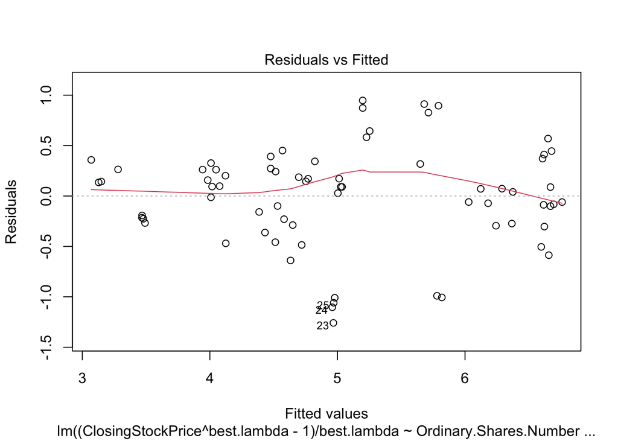

```r
# plotting the residual plot of the model
plot(model, which = 1)
```

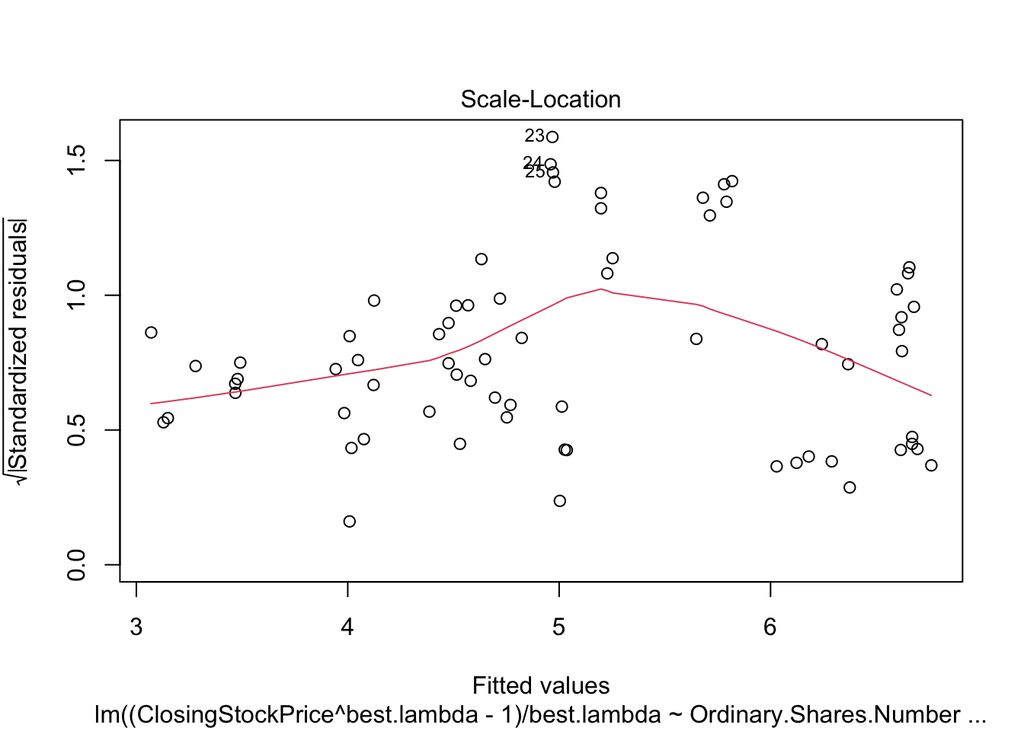

```r
# plotting the scale-location plot
plot(model, which = 3)
```

```r
# conducting the Breusch-Pagan test
bptest(model)
```

```
##
##  studentized Breusch-Pagan test
##
## data:  model
## BP = 12.024, df = 5, p-value = 0.03447
```

$H_0: $The Equal Variance Assumption is met.

$H_A: $The Equal Variance Assumption is not met.

It appears that the equal variance assumption is not met, as we reject the null hypothesis in the Breusch-Pagan test.

Independence Assumption:

Independence is assumed by default.

Multicollinearity Assumption:

```r
# conducting the vif test
imcdiag(model, method = "VIF")
```

```
##
## Call:
## imcdiag(mod = model, method = "VIF")
##
##
##  VIF Multicollinearity Diagnostics
##
##                                              VIF detection
## Ordinary.Shares.Number                    5.0600         0
## Total.Equity.Gross.Minority.Interest    111.8303         1
## Non.Current.Deferred.Taxes.Liabilities    7.2035         0
## Total.Liabilities.Net.Minority.Interest   6.8707         0
## Net.Tangible.Assets                      49.6070         1
##
## Multicollinearity may be due to Total.Equity.Gross.Minority.Interest Net.Tangible.Assets regressors
##
## 1 --> COLLINEARITY is detected by the test
## 0 --> COLLINEARITY is not detected by the test
##
## ===================================
```

It appears that the multicollinearity assumption is not met, as there is is collinearity present between 2 variables.

Outliers:

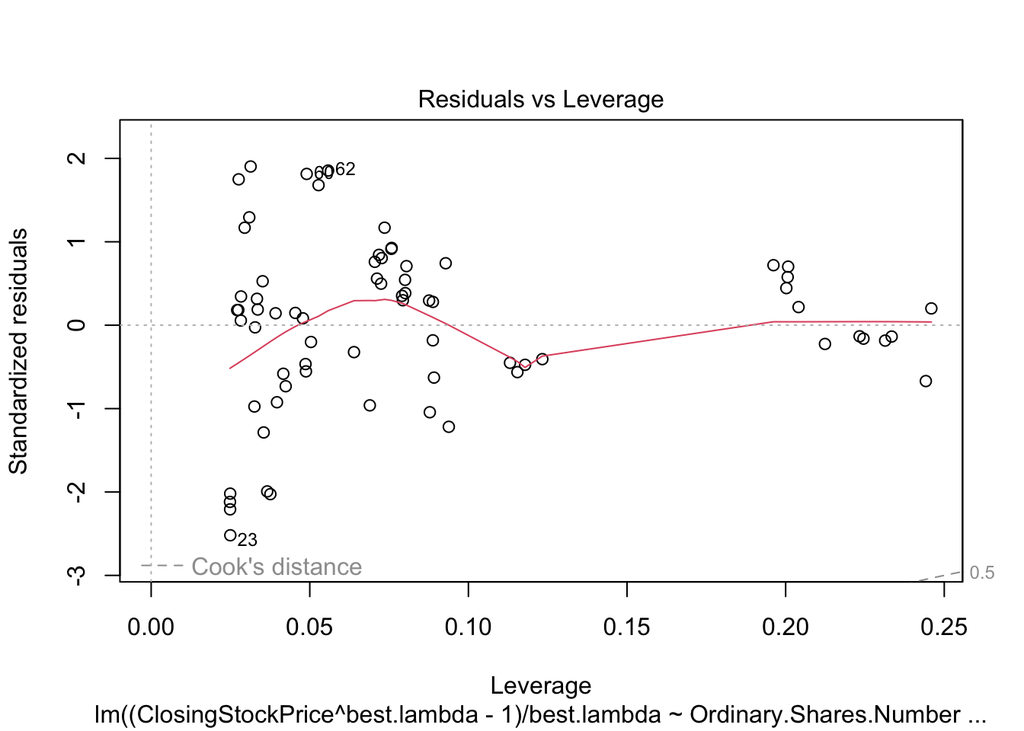

```r
# plotting the residual-leverage plot
plot(model, which = 5)
```

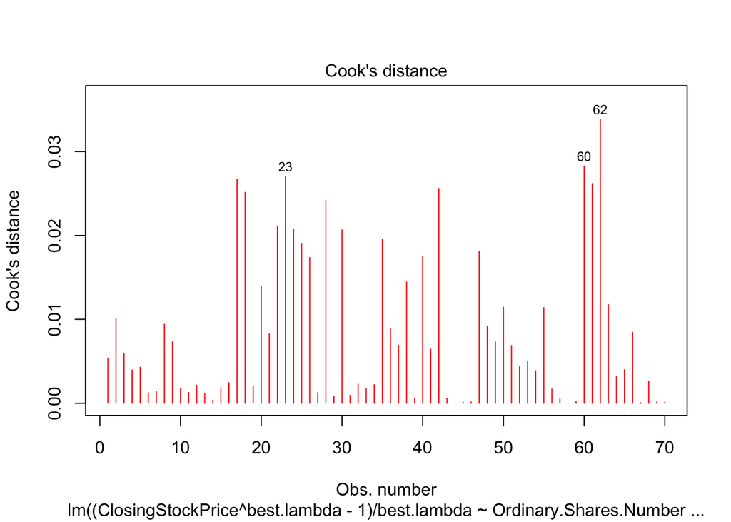

```r
# plotting the cooks distances
plot(model, pch = 18, col = "red", which = c(4))
```

It appears that the outlier assumption is met, as all cooks distances are below 0.5.

### Removing the collinear variable

```r
model = lm(formula = (ClosingStockPrice^best.lambda - 1)/best.lambda ~Ordinary.Shares.Number+Non.Current.Deferred.Taxes.Liabilities+Total.Liabilities.Net.Minority.Interest+Net.Tangible.Assets, data = data)
summary(model)
```

```
##
## Call:
## lm(formula = (ClosingStockPrice^best.lambda - 1)/best.lambda ~
##     Ordinary.Shares.Number + Non.Current.Deferred.Taxes.Liabilities +
##         Total.Liabilities.Net.Minority.Interest + Net.Tangible.Assets,
##     data = data)
##
## Residuals:
##      Min       1Q   Median       3Q      Max
## -1.44341 -0.49952 -0.01433  0.62881  1.09848
##
## Coefficients:
##                                                   Estimate         Std. Error
## (Intercept)                              5.870039996203392  0.177615946419425
## Ordinary.Shares.Number                  -0.000000001297695  0.000000000131017
## Non.Current.Deferred.Taxes.Liabilities  -0.000000000004424  0.000000000033079
## Total.Liabilities.Net.Minority.Interest -0.000000000002250  0.000000000002787
## Net.Tangible.Assets                      0.000000000026939  0.000000000004084
##                                         t value             Pr(>|t|)
## (Intercept)                              33.049 < 0.0000000000000002 ***
## Ordinary.Shares.Number                   -9.905    0.000000000000013 ***
## Non.Current.Deferred.Taxes.Liabilities   -0.134                0.894
## Total.Liabilities.Net.Minority.Interest  -0.808                0.422
## Net.Tangible.Assets                       6.596    0.000000008919256 ***
## ---
## Signif. codes:  0 '***' 0.001 '**' 0.01 '*' 0.05 '.' 0.1 ' ' 1
##
## Residual standard error: 0.7077 on 65 degrees of freedom
## Multiple R-squared:  0.665,  Adjusted R-squared:  0.6444
## F-statistic: 32.26 on 4 and 65 DF,  p-value: 0.000000000000008279
```

```r
# removing the insignificant variables
model = lm(formula = (ClosingStockPrice^best.lambda - 1)/best.lambda ~Ordinary.Shares.Number+Net.Tangible.Assets, data = data)
summary(model)
```

```
##
## Call:
## lm(formula = (ClosingStockPrice^best.lambda - 1)/best.lambda ~
##     Ordinary.Shares.Number + Net.Tangible.Assets, data = data)
##
## Residuals:
##      Min       1Q   Median       3Q      Max
## -1.41666 -0.59147 -0.02673  0.58282  1.17573
##
## Coefficients:
##                                  Estimate         Std. Error t value
## (Intercept)             5.801148751625592  0.150726224279045   38.49
## Ordinary.Shares.Number -0.000000001292602  0.000000000128644  -10.05
## Net.Tangible.Assets     0.000000000024233  0.000000000002232   10.86
##                                    Pr(>|t|)
## (Intercept)            < 0.0000000000000002 ***
## Ordinary.Shares.Number  0.00000000000000528 ***
## Net.Tangible.Assets    < 0.0000000000000002 ***
## ---
## Signif. codes:  0 '***' 0.001 '**' 0.01 '*' 0.05 '.' 0.1 ' ' 1
##
## Residual standard error: 0.7017 on 67 degrees of freedom
## Multiple R-squared:  0.6605, Adjusted R-squared:  0.6504
## F-statistic: 65.17 on 2 and 67 DF,  p-value: < 0.00000000000000022
```

### Condition Checking

Now, we must check the 6 core assumptions for the final model.

Linearity Assumption:

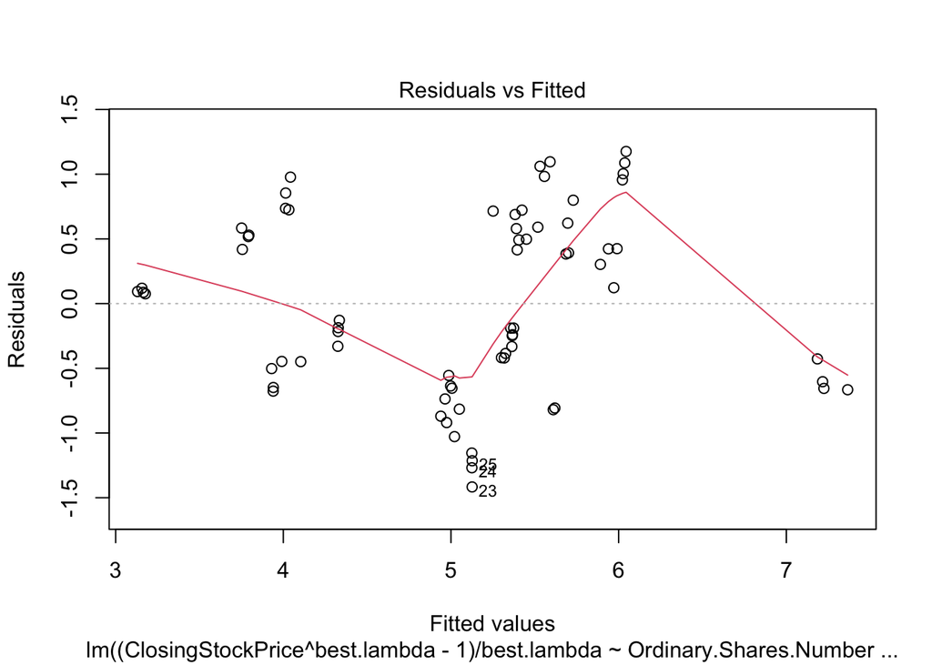

```r
# plotting the residual plot of the model
plot(model, which = 1)
```

It appears that the linearity assumption is not met, as the residual plot is not linear across all x values.

Normality Assumption:

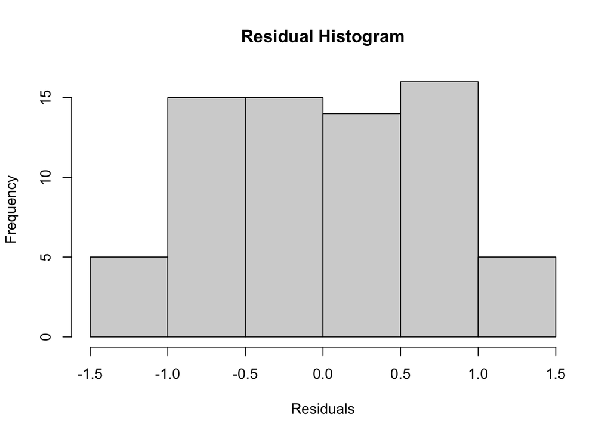

```r
# plotting the residual histogram
hist(residuals(model), main = "Residual Histogram", xlab = "Residuals")
```

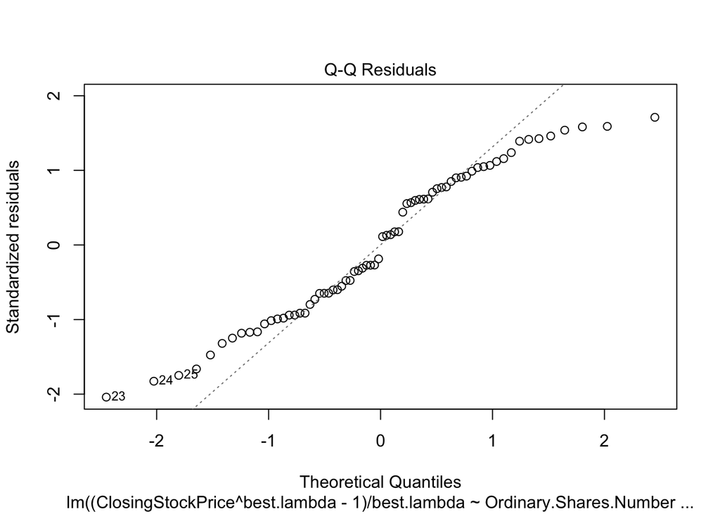

```r
# plotting the Q-Q normality plot
plot(model, which = 2)
```

```r
# conducting the Shapiro-Wilk normality test
shapiro.test(residuals(model))
```

```
##
##  Shapiro-Wilk normality test
##
## data:  residuals(model)
## W = 0.95767, p-value = 0.01865
```

$H_0: $ Normality of Residuals is met.

$H_A: $ Normality of Residuals is not met.

It appears that the normality of the residuals assumption is not met, as the histogram is not a bell-shape, the Q-Q normality plot is not following the diagonal line and we reject the null hypothesis in the Shapiro-Wilk normality test.

Equal Variance Assumption:

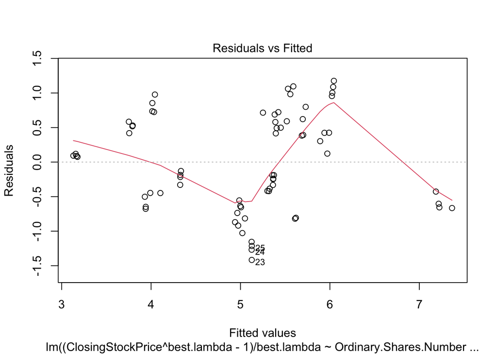

```r
# plotting the residual plot of the model
plot(model, which = 1)
```

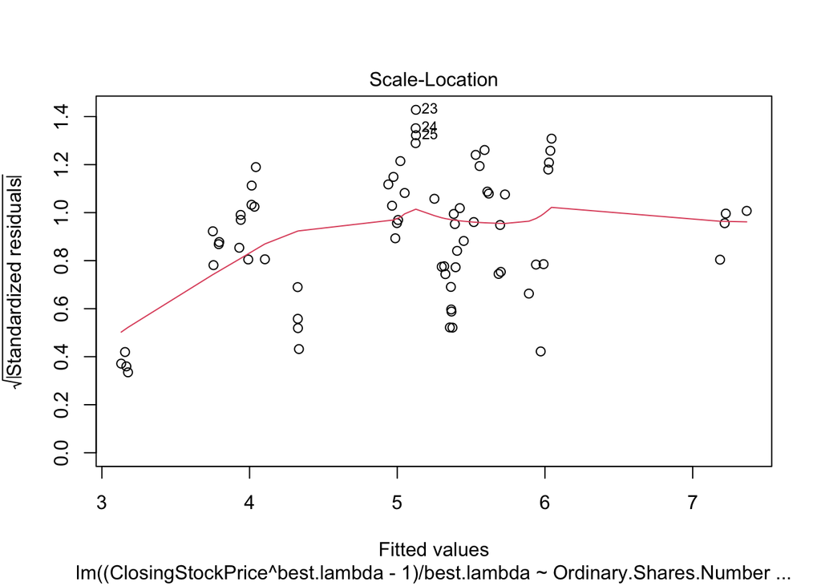

```r
# plotting the scale-location plot
plot(model, which = 3)
```

```r
# conducting the Breusch-Pagan test
bptest(model)
```

```
##
##  studentized Breusch-Pagan test
##
## data:  model
## BP = 7.7823, df = 2, p-value = 0.02042
```

$H_0: $The Equal Variance Assumption is met.

$H_A: $The Equal Variance Assumption is not met.

It appears that the equal variance assumption is not met, as the residual and scale-location plots are not equally varied for all x values, and we reject the null hypothesis in the Breusch-Pagan test.

Independence Assumption:

Independence is assumed by default.

Multicollinearity Assumption:

```r
# conducting the vif test
imcdiag(model, method = "VIF")
```

```
##
## Call:
## imcdiag(mod = model, method = "VIF")
##
##
##  VIF Multicollinearity Diagnostics
##
##                           VIF detection
## Ordinary.Shares.Number 1.9074         0
## Net.Tangible.Assets    1.9074         0
##
## NOTE:  VIF Method Failed to detect multicollinearity
##
##
## 0 --> COLLINEARITY is not detected by the test
##
## ===================================
```

It appears that the multicollinearity assumption is now met.

Outliers:

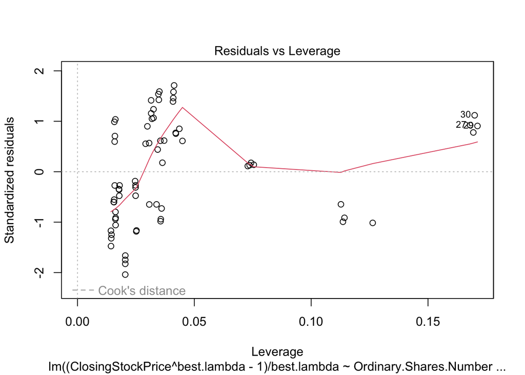

```r
# plotting the residual-leverage plot
plot(model, which = 5)
```

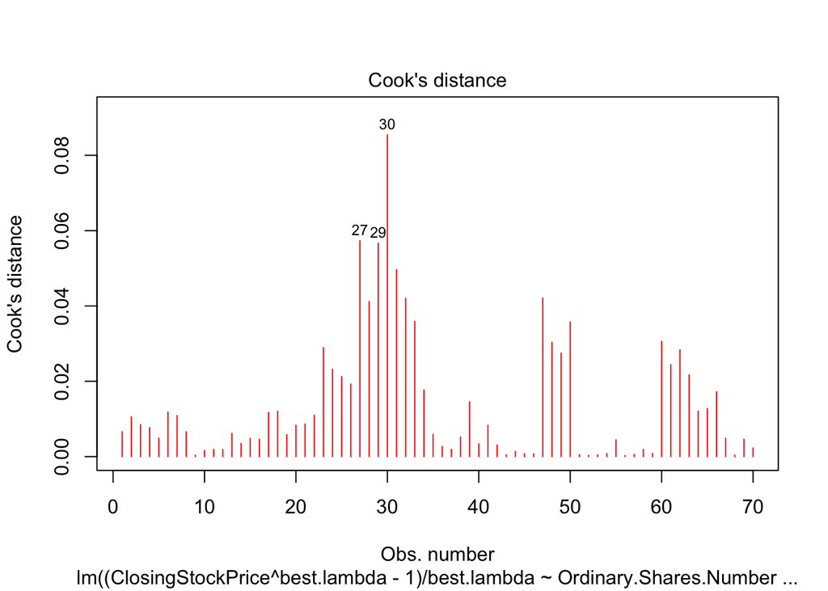

```r
# plotting the cooks distance values
plot(model, pch = 18, col = "red", which = c(4))
```

It appears that the outlier assumption is met.

### Results

In summarizing the project, we encountered challenges in constructing a robust regression model. These challenges included a scarcity of strong variable predictors and difficulties in meeting various regression model assumptions, both before and after applying a Box-Cox transformation. Notably, our findings indicate that company balance sheets lack efficacy as predictors for the closing stock prices of Canadian oil and gas companies. This limitation arises from the fact that most balance sheet values exhibit an insignificant relationship with the closing stock price. Additionally, those few balance sheet values that do demonstrate a significant relationship fail to satisfy fundamental regression requirements such as the equal variance and normality of residuals assumptions, rendering the model unsuitable for predictive purposes. These insights underscore the importance of exploring factors beyond financial statement values when evaluating potential investments in the oil and gas sector. Investors are encouraged to delve deeper into a company’s mission statement, social media activity, management history, and other non-financial aspects to make more informed investing decisions.

### Conclusion

In conclusion, it appears that balance sheets may not be a reliable predictor for the closing stock prices of Canadian oil and gas companies. This is likely due to the influence of extraneous factors beyond the numerical values presented in financial statements that significantly impact the closing stock prices.

### References

Yfinance. PyPI. (2023). https://pypi.org/project/yfinance/